# Wine Quality Analysis and Data Preparation

## 11.2 Odds Ratios

```r
odds_ratios <- exp(coef(logit_model))
odds_ratios
```

```
##          (Intercept)        fixed.acidity     volatile.acidity
##         2.385707e+52         1.257763e+00         7.805875e-03
##          citric.acid       residual.sugar            chlorides
##         5.863019e-01         1.138581e+00         2.258630e-04
##  free.sulfur.dioxide total.sulfur.dioxide              density
##         1.020003e+00         9.765116e-01         3.652673e-59
##                   pH            sulphates              alcohol
##         6.773135e-01         4.481641e+01         2.915810e+00
```

```r
or_ci <- exp(cbind(OR = coef(logit_model), confint(logit_model)))
or_ci
```

```
##                                OR         2.5 %        97.5 %
## (Intercept)          2.385707e+52  3.068067e-78 1.065216e+183
## fixed.acidity        1.257763e+00  9.086506e-01  1.741104e+00
## volatile.acidity     7.805875e-03  6.956989e-04  7.719941e-02
## citric.acid          5.863019e-01  5.342154e-02  6.282086e+00
## residual.sugar       1.138581e+00  8.866013e-01  1.415258e+00
## chlorides            2.258630e-04  2.941095e-09  5.844953e-01
## free.sulfur.dioxide  1.020003e+00  9.863214e-01  1.055100e+00
## total.sulfur.dioxide 9.765116e-01  9.608044e-01  9.910418e-01
## density              3.652673e-59 1.941936e-192  1.056902e+74
## pH                   6.773135e-01  4.239172e-02  1.023095e+01
## sulphates            4.481641e+01  9.543591e+00  2.104817e+02
## alcohol              2.915810e+00  2.013445e+00  4.286525e+00
```

## 11.3 Validation: Predict Probabilities

```r
valid_prob <- predict(logit_model, newdata = valid, type = "response")
head(valid_prob)
```

```
##           4           6           7           8          14          18
## 0.058192394 0.004359579 0.003853783 0.015813983 0.143089399 0.008104430
```

## 11.4 Validation: ROC & AUC

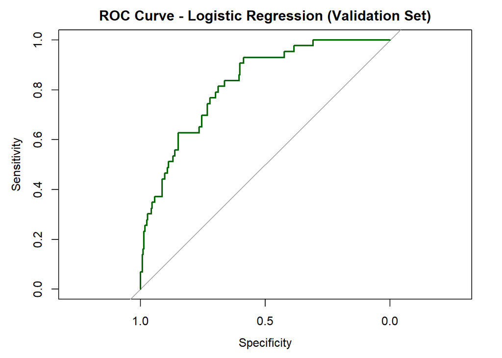

```r
roc_valid <- roc(
  response = valid$quality_binary,
  predictor = valid_prob,
  levels = c("Poor", "Premium"),
  direction = "<"
)

plot(roc_valid, col = "darkgreen", main = "ROC Curve - Logistic Regression (Validation Set)")
```

```r
auc(roc_valid)
```

```
## Area under the curve: 0.8236
```

## 11.5 Validation: Choose Threshold (Youden)

```r
best_valid <- coords(
  roc_valid,
  "best",
  ret = c("threshold", "sensitivity", "specificity"),
  best.method = "youden"
)
best_valid
```

```
##    threshold sensitivity specificity
## 1 0.03720762   0.9302326   0.5869565
```

## 11.6 Validation: Confusion Matrix (Default 0.5 vs Best Threshold)

```r
# Default threshold
pred_valid_05 <- ifelse(valid_prob >= 0.5, "Premium", "Poor")
pred_valid_05 <- factor(pred_valid_05, levels = c("Poor", "Premium"))

cm_valid_05 <- confusionMatrix(pred_valid_05, valid$quality_binary, positive = "Premium")
cm_valid_05
```

```
## Confusion Matrix and Statistics
##
##           Reference
## Prediction Poor Premium
##    Poor     263      28
##    Premium   13      15
##
##                Accuracy : 0.8715
##                  95% CI : (0.8297, 0.9062)
##     No Information Rate : 0.8652
##     P-Value [Acc > NIR] : 0.41023
##
##                   Kappa : 0.3538
##
##  Mcnemar's Test P-Value : 0.02878
##
##             Sensitivity : 0.34884
##             Specificity : 0.95290
##          Pos Pred Value : 0.53571
##          Neg Pred Value : 0.90378
##              Prevalence : 0.13480
##          Detection Rate : 0.04702
##    Detection Prevalence : 0.08777
##       Balanced Accuracy : 0.65087
##
##        'Positive' Class : Premium
##
```

```r
# Best threshold from ROC
best_thr <- as.numeric(best_valid["threshold"])

pred_valid_best <- ifelse(valid_prob >= best_thr, "Premium", "Poor")
pred_valid_best <- factor(pred_valid_best, levels = c("Poor", "Premium"))

cm_valid_best <- confusionMatrix(pred_valid_best, valid$quality_binary, positive = "Premium")
cm_valid_best
```

```
## Confusion Matrix and Statistics
##
##           Reference
## Prediction Poor Premium
##    Poor     162       3
##    Premium  114      40
##
##                Accuracy : 0.6332
##                  95% CI : (0.5777, 0.6862)
##     No Information Rate : 0.8652
##     P-Value [Acc > NIR] : 1
##
##                   Kappa : 0.2475
##
##  Mcnemar's Test P-Value : <2e-16
##
##             Sensitivity : 0.9302
##             Specificity : 0.5870
##          Pos Pred Value : 0.2597
##          Neg Pred Value : 0.9818
##              Prevalence : 0.1348
##          Detection Rate : 0.1254
##    Detection Prevalence : 0.4828
##       Balanced Accuracy : 0.7586
##
##        'Positive' Class : Premium
##
```

## 11.7 Final Test Evaluation (Use Test Only Once)

```r
test_prob <- predict(logit_model, newdata = test, type = "response")

test_pred <- ifelse(test_prob >= best_thr, "Premium", "Poor")
test_pred <- factor(test_pred, levels = c("Poor", "Premium"))

cm_test <- confusionMatrix(test_pred, test$quality_binary, positive = "Premium")
cm_test
```

```
## Confusion Matrix and Statistics
##
##           Reference
## Prediction Poor Premium
##    Poor     147       4
##    Premium  129      39
##
##                Accuracy : 0.5831
##                  95% CI : (0.5268, 0.6378)
##     No Information Rate : 0.8652
##     P-Value [Acc > NIR] : 1
##
##                   Kappa : 0.1974
##
##  Mcnemar's Test P-Value : <2e-16
##
##             Sensitivity : 0.9070
##             Specificity : 0.5326
##          Pos Pred Value : 0.2321
##          Neg Pred Value : 0.9735
##              Prevalence : 0.1348
##          Detection Rate : 0.1223
##    Detection Prevalence : 0.5266
##       Balanced Accuracy : 0.7198
##
##        'Positive' Class : Premium
##
```

## 11.8 Test: ROC & AUC

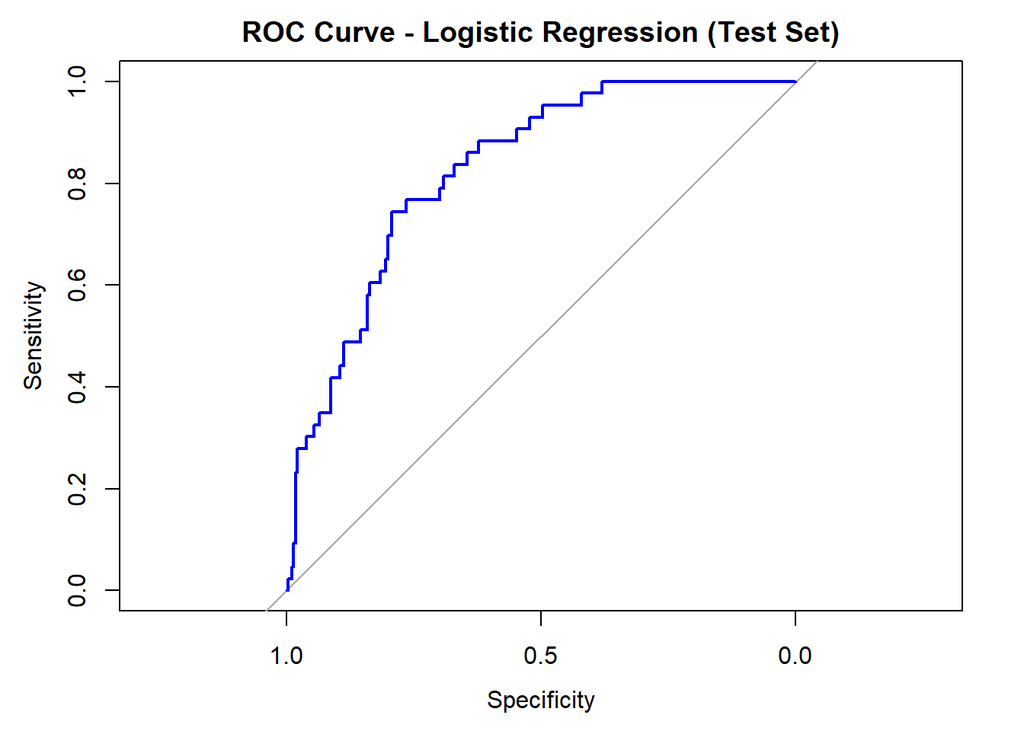

```r
roc_test <- roc(
  response = test$quality_binary,
  predictor = test_prob,
  levels = c("Poor", "Premium"),
  direction = "<"
)

plot(roc_test, col = "blue", main = "ROC Curve - Logistic Regression (Test Set)")
```

```r
auc(roc_test)
```

```
## Area under the curve: 0.8264
```

# 12 ML2: Support Vector Machine (SVM) Model (Wine Quality)

## 12.1 Packages

```r
# If needed, install packages once in the R console, e.g.:
# install.packages(c("here","caret","pROC","dplyr","kernlab"))
```

## 12.2 Fit SVM (Radial) Model

```r
# 3) Fit SVM (Radial) with CV tuning on TRAIN only
# SVM is sensitive to scaling -> preProcess centers/scales predictors
ctrl <- trainControl(
  method = "cv",
  number = 5,
  classProbs = TRUE,
  summaryFunction = twoClassSummary,
  savePredictions = "final"
)

svm_grid <- expand.grid(
  sigma = c(0.005, 0.01, 0.02, 0.05),
  C     = c(0.5, 1, 2, 5, 10)
)

svm_model <- train(
  quality_binary ~ .,
  data = train,
  method = "svmRadial",
  preProcess = c("center", "scale"),
  metric = "ROC",
  trControl = ctrl,
  tuneGrid = svm_grid
)

svm_model
```

```
## Support Vector Machines with Radial Basis Function Kernel
##
## 961 samples
##  11 predictor
##   2 classes: 'Poor', 'Premium'
##
## Pre-processing: centered (11), scaled (11)
## Resampling: Cross-Validated (5 fold)
## Summary of sample sizes: 769, 769, 769, 769, 768
## Resampling results across tuning parameters:
##
##   sigma  C     ROC        Sens       Spec
##   0.005   0.5  0.9005114  0.9518072  0.4133903
##   0.005   1.0  0.9005595  0.9590361  0.4364672
##   0.005   2.0  0.9005595  0.9578313  0.4421652
##   0.005   5.0  0.9003741  0.9554217  0.4427350
##   0.005  10.0  0.9002489  0.9686747  0.3968661
##   0.010   0.5  0.9004737  0.9626506  0.4125356
##   0.010   1.0  0.9005664  0.9614458  0.4415954
##   0.010   2.0  0.9008907  0.9506024  0.4729345
##   0.010   5.0  0.9016716  0.9686747  0.3746439
##   0.010  10.0  0.9007140  0.9674699  0.3823362
##   0.020   0.5  0.9008393  0.9542169  0.4877493
##   0.020   1.0  0.9009336  0.9590361  0.4424501
##   0.020   2.0  0.9015858  0.9662651  0.3894587
##   0.020   5.0  0.8991161  0.9674699  0.4122507
##   0.020  10.0  0.8969897  0.9710843  0.3894587
##   0.050   0.5  0.8975011  0.9590361  0.4957265
##   0.050   1.0  0.8972437  0.9662651  0.4347578
##   0.050   2.0  0.8920640  0.9698795  0.4119658
##   0.050   5.0  0.8882384  0.9734940  0.4051282
##   0.050  10.0  0.8851183  0.9771084  0.4430199
##
## ROC was used to select the optimal model using the largest value.
## The final values used for the model were sigma = 0.01 and C = 5.
```

```r
svm_model$bestTune
```

```
##   sigma C
## 9  0.01 5
```

## 12.3 Predict Probabilities

```r
# 4) Predict probabilities
svm_valid_prob <- predict(svm_model, newdata = valid, type = "prob")[, "Premium"]
svm_test_prob  <- predict(svm_model, newdata = test,  type = "prob")[, "Premium"]
```

## 12.4 Choose Threshold (Validation Set)

```r
# 5) Choose threshold using Validation set (Youden's J from ROC)
svm_roc_valid <- roc(
  response = valid$quality_binary,
  predictor = svm_valid_prob,
  levels = c("Poor","Premium"),
  direction = "<"
)


best <- coords(
  svm_roc_valid,
  x = "best",
  best.method = "youden",
  transpose = FALSE
)

best_thresh <- as.numeric(best["threshold"])
best_thresh
```

```
## [1] 0.06260706
```

## 12.5 Class Predictions

```r
# 6) Class predictions using chosen threshold
valid_pred <- factor(ifelse(svm_valid_prob >= best_thresh, "Premium", "Poor"),
                     levels = c("Poor","Premium"))

test_pred  <- factor(ifelse(svm_test_prob >= best_thresh, "Premium", "Poor"),
                     levels = c("Poor","Premium"))
```

## 12.6 Model Evaluation

```r
# 7) Evaluation (Validation)
confusionMatrix(valid_pred, valid$quality_binary, positive = "Premium")
```

```
## Confusion Matrix and Statistics
##
##           Reference
## Prediction Poor Premium
##    Poor     174       2
##    Premium  102      41
##
##                Accuracy : 0.674
##                  95% CI : (0.6195, 0.7252)
##     No Information Rate : 0.8652
##     P-Value [Acc > NIR] : 1
##
##                   Kappa : 0.2947
##
##  Mcnemar's Test P-Value : <2e-16
##
##             Sensitivity : 0.9535
##             Specificity : 0.6304
##          Pos Pred Value : 0.2867
##          Neg Pred Value : 0.9886
##              Prevalence : 0.1348
##          Detection Rate : 0.1285
##    Detection Prevalence : 0.4483
##       Balanced Accuracy : 0.7920
##
##        'Positive' Class : Premium
##
```

```r
svm_auc_valid <- auc(svm_roc_valid)
svm_auc_valid
```

```
## Area under the curve: 0.8423
```

```r
# 8) Final Evaluation (TEST ONLY)
svm_roc_test <- roc(
  response = test$quality_binary,
  predictor = svm_test_prob,
  levels = c("Poor","Premium"),
  direction = "<"
)

svm_auc_test <- auc(svm_roc_test)
svm_auc_test
```

```
## Area under the curve: 0.8074
```

```r
confusionMatrix(test_pred, test$quality_binary, positive = "Premium")
```

```
## Confusion Matrix and Statistics
##
##           Reference
## Prediction Poor Premium
##    Poor     149       4
##    Premium  127      39
##
##                Accuracy : 0.5893
##                  95% CI : (0.5332, 0.6438)
##     No Information Rate : 0.8652
##     P-Value [Acc > NIR] : 1
##
##                   Kappa : 0.2024
##
##  Mcnemar's Test P-Value : <2e-16
##
##             Sensitivity : 0.9070
##             Specificity : 0.5399
##          Pos Pred Value : 0.2349
##          Neg Pred Value : 0.9739
##              Prevalence : 0.1348
##          Detection Rate : 0.1223
##    Detection Prevalence : 0.5204
##       Balanced Accuracy : 0.7234
##
##        'Positive' Class : Premium
##
```

## 12.7 ROC Plot (Test Set)

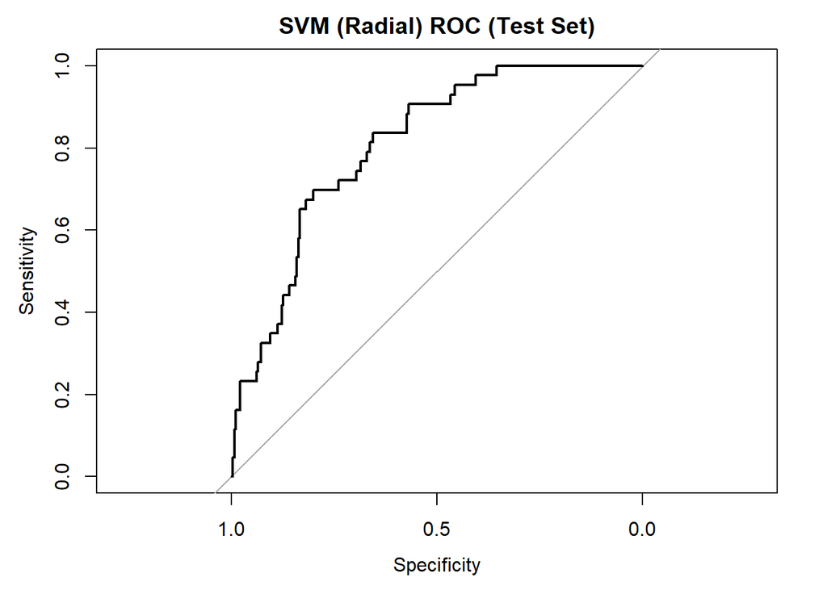

```r
# 9) Optional: ROC plot (test)
plot(svm_roc_test, main = "SVM (Radial) ROC (Test Set)")
```

# (c) Fair Comparison of Logistic Regression vs SVM (Test Set)

```r
# --- Logistic Regression: compute test predictions + metrics using best_thr ---
# (These variables already exist from your LR section: test_prob, best_thr, roc_test)
logit_test_prob <- test_prob
logit_thr <- best_thr

logit_test_pred <- factor(
  ifelse(logit_test_prob >= logit_thr, "Premium", "Poor"),
  levels = c("Poor", "Premium")
)

cm_logit_test <- confusionMatrix(logit_test_pred, test$quality_binary, positive = "Premium")

# AUC for Logistic Regression (already computed as auc(roc_test), but we store it)
auc_logit_test <- as.numeric(auc(roc_test))


# --- SVM: compute metrics using best_thresh ---
# (These variables already exist from your SVM section: svm_test_prob, best_thresh, svm_roc_test)
svm_test_pred2 <- factor(
  ifelse(svm_test_prob >= best_thresh, "Premium", "Poor"),
  levels = c("Poor", "Premium")
)

cm_svm_test <- confusionMatrix(svm_test_pred2, test$quality_binary, positive = "Premium")
auc_svm_test <- as.numeric(auc(svm_roc_test))


# --- Create a fair side-by-side table (Premium is the positive class) ---
compare_table <- data.frame(
  Model = c("Logistic Regression", "SVM (Radial)"),
  Test_AUC = c(auc_logit_test, auc_svm_test),
  Precision_Premium = c(cm_logit_test$byClass["Precision"], cm_svm_test$byClass["Precision"]),
  Recall_Premium    = c(cm_logit_test$byClass["Recall"],    cm_svm_test$byClass["Recall"]),
  F1_Premium        = c(cm_logit_test$byClass["F1"],        cm_svm_test$byClass["F1"]),
  Balanced_Accuracy = c(cm_logit_test$byClass["Balanced Accuracy"], cm_svm_test$byClass["Balanced Accuracy"])
)

compare_table
```

```
##                 Model  Test_AUC Precision_Premium Recall_Premium F1_Premium
## 1 Logistic Regression 0.8264240         0.2321429      0.9069767  0.3696682
## 2        SVM (Radial) 0.8073812         0.2349398      0.9069767  0.3732057
##   Balanced_Accuracy
## 1         0.7197927
## 2         0.7234159
```

**Test-set comparison :**  
The table compares Logistic Regression and the Radial SVM on the same held-out test set using ROC-AUC and threshold-based metrics focused on the minority class (*Premium*). Logistic Regression achieves a slightly higher **Test AUC** (0.826) than SVM (0.807), indicating better overall ranking/discrimination across thresholds. Using the validation-selected thresholds, both models reach the same **Recall for Premium** (0.907), meaning they successfully identify most Premium wines. However, **Precision** is low for both models (~0.23), showing that many wines predicted as Premium are actually Poor, which is expected in an imbalanced setting. The SVM shows a marginally higher **F1-score** (0.373 vs 0.370) and **Balanced Accuracy** (0.723 vs 0.720), but the differences are very small. Overall, Logistic Regression is preferable if we prioritize global discrimination (AUC), while SVM offers a slight advantage in threshold-based classification metrics; given the minimal gap, model choice can be guided by the preferred objective and interpretability considerations.

# 13 Model-Agnostic XAI for Logistic Regression and SVM

```r
# Use same training data as for the models
x_train <- train %>% dplyr::select(-quality_binary)
y_train <- ifelse(train$quality_binary == "Premium", 1, 0)

# Explainer for Logistic Regression (probability of Premium)
explainer_logit <- explain(
  model            = logit_model,
  data             = x_train,
  y                = y_train,
  label            = "Logistic Regression",
  predict_function = function(m, newdata) {
    predict(m, newdata, type = "response")
  }
)
```

```
## Preparation of a new explainer is initiated
##   -> model label       :  Logistic Regression
##   -> data              :  961  rows  11  cols
##   -> target variable   :  961  values
##   -> predict function  :  function(m, newdata) {     predict(m, newdata, type = "response") }
##   -> predicted values  :  No value for predict function target column. (  default  )
##   -> model_info        :  package stats , ver. 4.4.2 , task classification (  default  )
##   -> predicted values  :  numerical, min =  4.361108e-05 , mean =  0.1363163 , max =  0.9919657
##   -> residual function :  difference between y and yhat (  default  )
##   -> residuals         :  numerical, min =  -0.9919657 , mean =  -1.23071e-14 , max =  0.9957155
##   A new explainer has been created!
```

```r
# Explainer for SVM (caret::train with svmRadial, probability of Premium)
explainer_svm <- explain(
  model            = svm_model,
  data             = x_train,
  y                = y_train,
  label            = "SVM (Radial)",
  predict_function = function(m, newdata) {
    predict(m, newdata, type = "prob")[, "Premium"]
  }
)
```

```
## Preparation of a new explainer is initiated
##   -> model label       :  SVM (Radial)
##   -> data              :  961  rows  11  cols
##   -> target variable   :  961  values
##   -> predict function  :  function(m, newdata) {     predict(m, newdata, type = "prob")[, "Premium"] }
##   -> predicted values  :  No value for predict function target column. (  default  )
##   -> model_info        :  package caret , ver. 7.0.1 , task classification (  default  )
##   -> predicted values  :  numerical, min =  0.003026962 , mean =  0.1380669 , max =  0.9334798
##   -> residual function :  difference between y and yhat (  default  )
##   -> residuals         :  numerical, min =  -0.8933526 , mean =  -0.0017506 , max =  0.9737812
##   A new explainer has been created!
```

# 14 Global permutation feature importance for both models

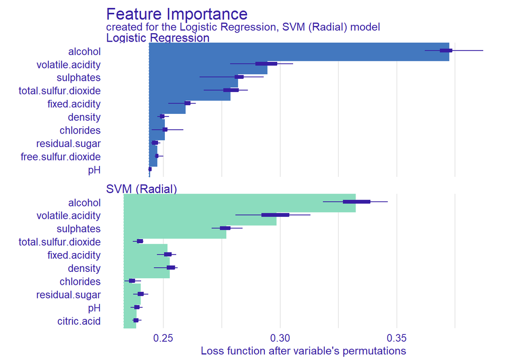

```r
# Custom binary cross-entropy loss for numeric 0/1 target and probability predictions
loss_bce <- function(observed, predicted) {
  eps <- 1e-15
  predicted <- pmin(pmax(predicted, eps), 1 - eps)
  -mean(observed * log(predicted) + (1 - observed) * log(1 - predicted))
}

fi_logit <- model_parts(
  explainer_logit,
  type = "variable_importance",
  loss_function = loss_bce
)

fi_svm <- model_parts(
  explainer_svm,
  type = "variable_importance",
  loss_function = loss_bce
)

# Side-by-side comparison (top variables)
plot(fi_logit, fi_svm, max_vars = 10)
```

```r
fi_logit
```

```
##                variable mean_dropout_loss               label
## 1          _full_model_         0.2438041 Logistic Regression
## 2           citric.acid         0.2438384 Logistic Regression
## 3                    pH         0.2442325 Logistic Regression
## 4        residual.sugar         0.2465280 Logistic Regression
## 5   free.sulfur.dioxide         0.2473920 Logistic Regression
## 6               density         0.2495123 Logistic Regression
## 7             chlorides         0.2505755 Logistic Regression
## 8         fixed.acidity         0.2594643 Logistic Regression
## 9  total.sulfur.dioxide         0.2787679 Logistic Regression
## 10            sulphates         0.2820188 Logistic Regression
## 11     volatile.acidity         0.2945667 Logistic Regression
## 12              alcohol         0.3724390 Logistic Regression
## 13           _baseline_         0.6316592 Logistic Regression
```

```r
fi_svm
```

```
##                variable mean_dropout_loss        label
## 1          _full_model_         0.2329904 SVM (Radial)
## 2   free.sulfur.dioxide         0.2365272 SVM (Radial)
## 3             chlorides         0.2365547 SVM (Radial)
## 4           citric.acid         0.2383189 SVM (Radial)
## 5                    pH         0.2384937 SVM (Radial)
## 6  total.sulfur.dioxide         0.2396464 SVM (Radial)
## 7        residual.sugar         0.2402040 SVM (Radial)
## 8         fixed.acidity         0.2516354 SVM (Radial)
## 9               density         0.2527054 SVM (Radial)
## 10            sulphates         0.2769704 SVM (Radial)
## 11     volatile.acidity         0.2983792 SVM (Radial)
## 12              alcohol         0.3323704 SVM (Radial)
## 13           _baseline_         0.5546376 SVM (Radial)
```

# 15 Choose a few key variables for detailed effect plots

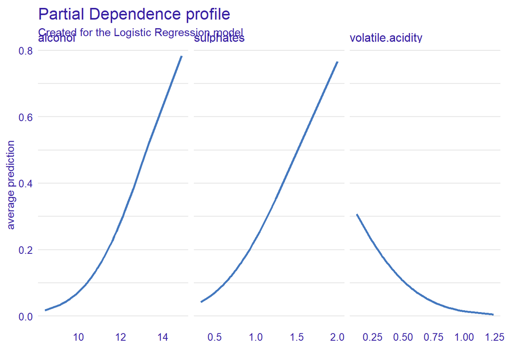

```r
vars_of_interest <- c("alcohol", "sulphates", "volatile.acidity")

# Partial dependence profiles
pdp_logit <- model_profile(
  explainer_logit,
  variables = vars_of_interest,
  type      = "partial"
)

pdp_svm <- model_profile(
  explainer_svm,
  variables = vars_of_interest,
  type      = "partial"
)

# Plot PDPs for each model
plot(pdp_logit)
```

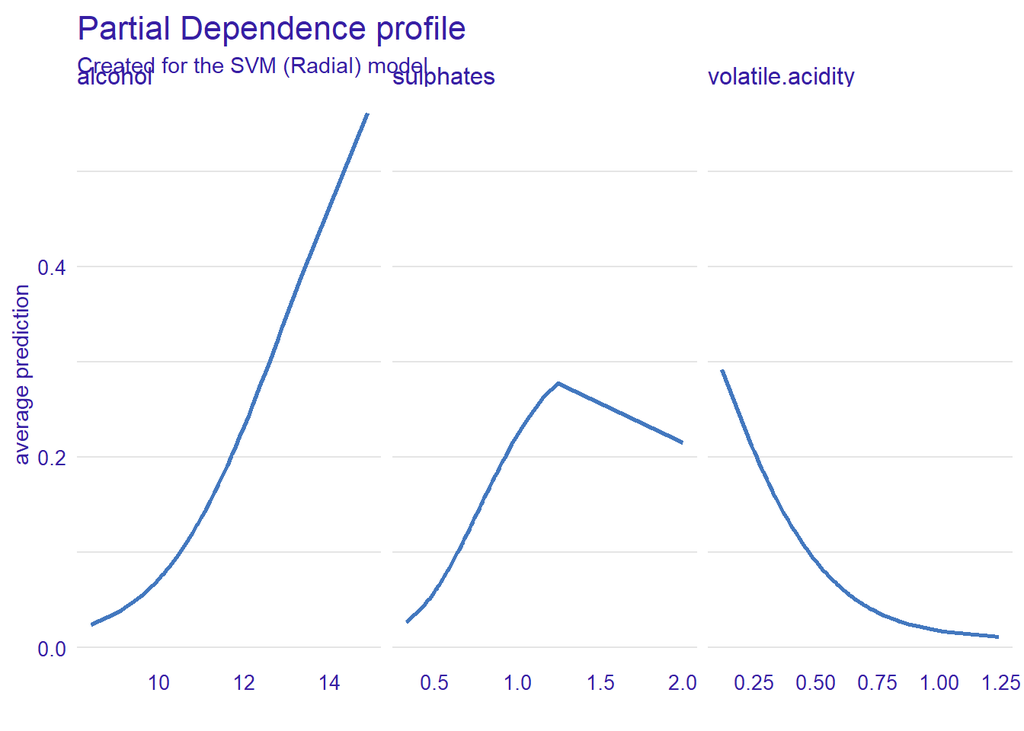

```r
plot(pdp_svm)
```

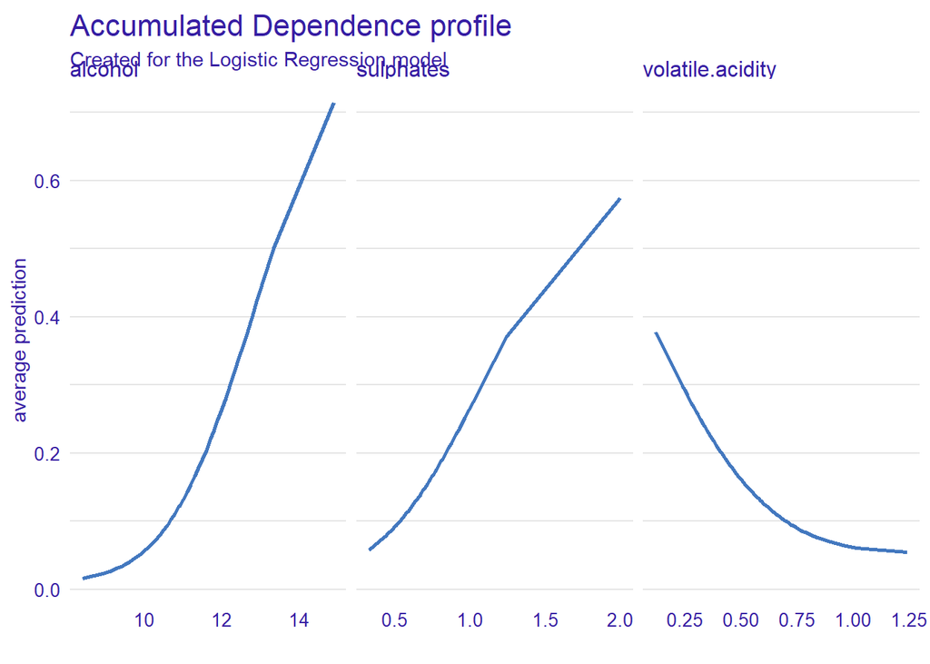

```r
# (Alternative: ALE profiles instead of PDPs)
ale_logit <- model_profile(
  explainer_logit,
  variables = vars_of_interest,
  type      = "accumulated"
)

ale_svm <- model_profile(
  explainer_svm,
  variables = vars_of_interest,
  type      = "accumulated"
)

plot(ale_logit)
```

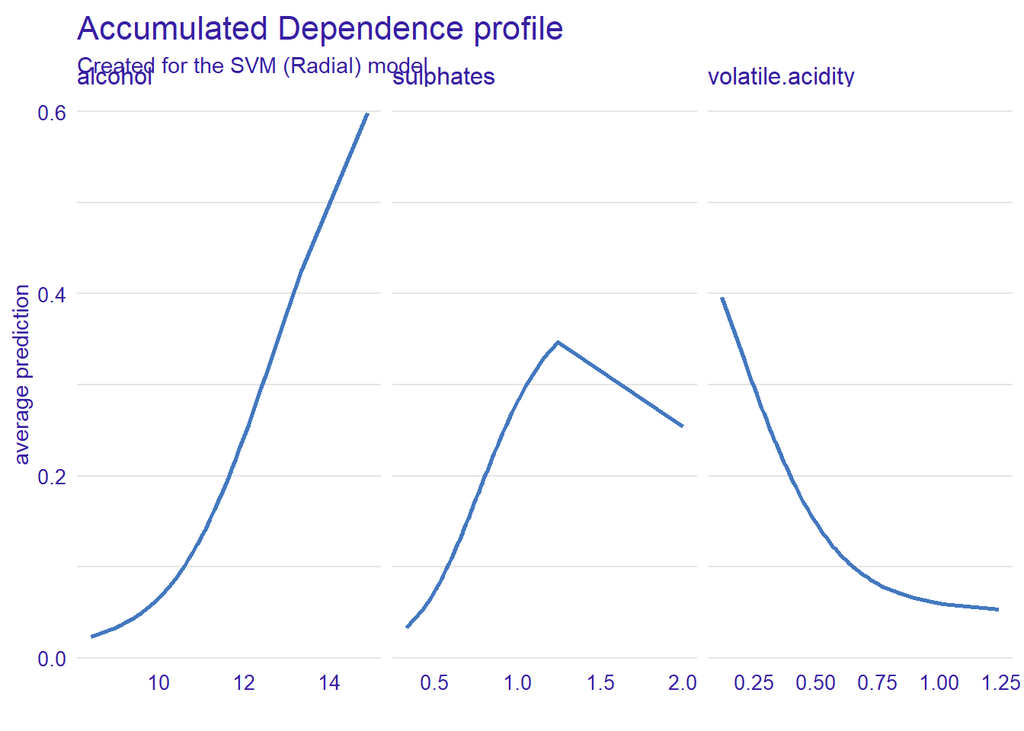

```r
plot(ale_svm)
```

# Microscopic (Local) Explanations for Individual Wines

```r
set.seed(123)
```

```r
example_idx <- sample(seq_len(nrow(test)), 3)
local_obs   <- test[example_idx, ]
local_x     <- local_obs %>% dplyr::select(-quality_binary)
local_y     <- local_obs$quality_binary
local_obs
```

```
##     fixed.acidity volatile.acidity citric.acid residual.sugar chlorides
## 897           8.3             0.31        0.39            2.4     0.078
## 126           9.0             0.62        0.04            1.9     0.146
## 955           7.6             0.43        0.40            2.7     0.082
##     free.sulfur.dioxide total.sulfur.dioxide density   pH sulphates alcohol
## 897                  17                   43 0.99444 3.31      0.77    12.5
## 126                  27                   90 0.99840 3.16      0.70     9.4
## 955                   6                   11 0.99538 3.44      0.54    12.2
##     quality_binary
## 897        Premium
## 126           Poor
## 955           Poor
```

```r
local_y
```

```
## [1] Premium Poor    Poor
## Levels: Poor Premium
```

# 16 Break-down (additive) explanations for Logistic Regression

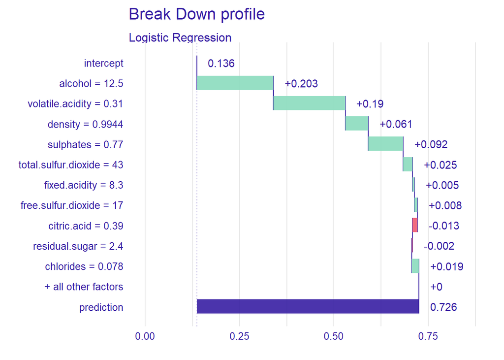

```r
# Break-down (additive) explanations for Logistic Regression
bd_logit <- predict_parts(
  explainer_logit,
  new_observation = local_x[1, , drop = FALSE],
  type            = "break_down"
)

# Break-down explanations for SVM
bd_svm <- predict_parts(
  explainer_svm,
  new_observation = local_x[1, , drop = FALSE],
  type            = "break_down"
)

plot(bd_logit)
```

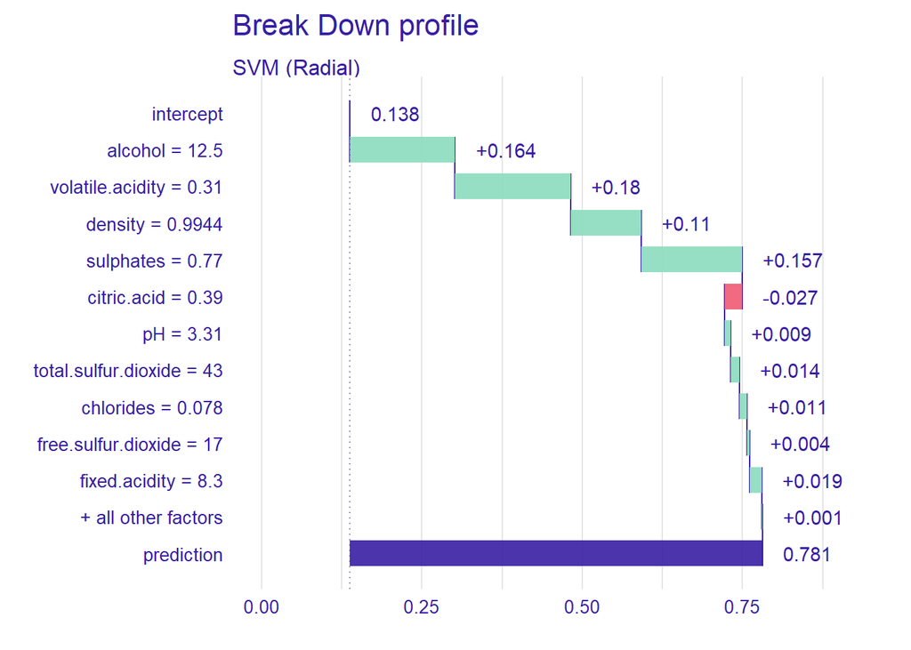

```r
plot(bd_svm)
```

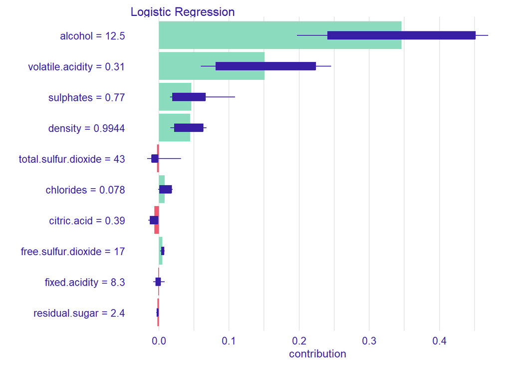

```r
# SHAP-like local explanations (can be slower)
shap_logit <- predict_parts(
  explainer_logit,
  new_observation = local_x[1, , drop = FALSE],
  type            = "shap"
)

shap_svm <- predict_parts(
  explainer_svm,
  new_observation = local_x[1, , drop = FALSE],
  type            = "shap"
)

plot(shap_logit)
```

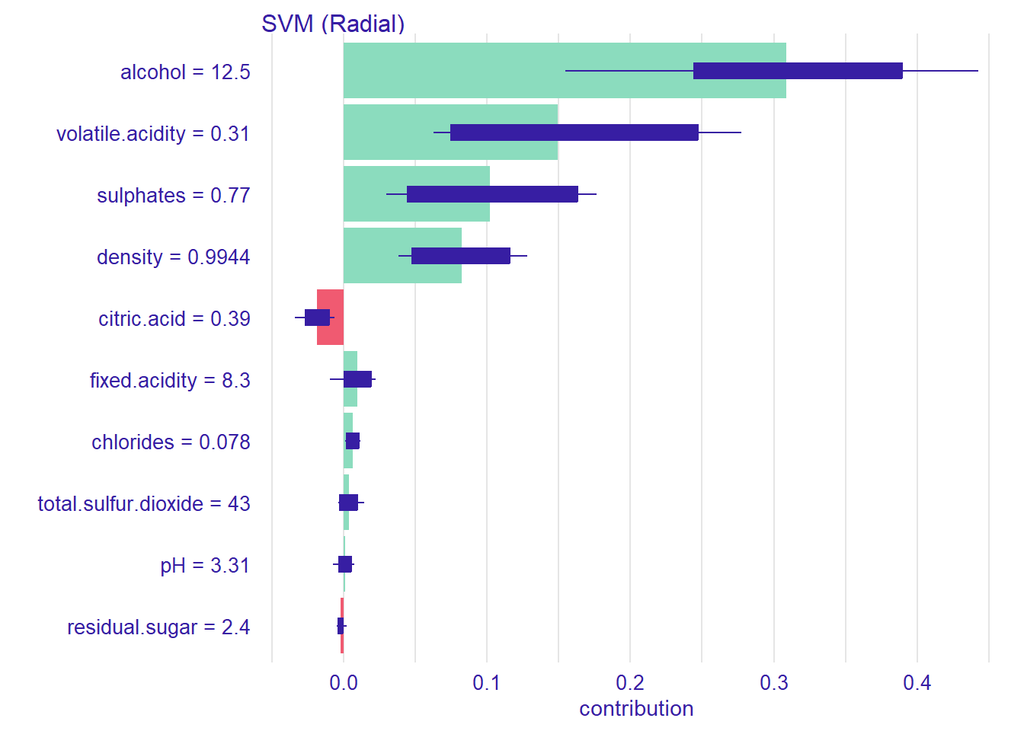

```r
plot(shap_svm)
```

# 17 References

- Iowa State University Extension. (2021). [Understanding Wine Quality Parameters](https://www.extension.iastate.edu/wine/wp-content/uploads/2021/09/FS40.pdf).
- Cortez, P. (2018). [Modeling wine preferences by data mining from physicochemical properties](https://www.nature.com/articles/s41598-018-19185-5). *Scientific Reports*.
- Vinetur. (2025). [Sulfur in winemaking: Industry divided over impact on taste and quality](https://www.vinetur.com/en/2025012084084/sulfur-in-winemaking-industry-divided-over-impact-on-taste-and-quality.html).
- Cortez, P., Cerdeira, A., Almeida, F., Matos, T., & Reis, J. (2009). Modeling wine preferences by data mining from physicochemical properties. *Decision Support Systems*, 47(4), 547-553. https://doi.org/10.1016/j.dss.2009.05.016
- Kuhn, M. (2008). Building Predictive Models in R Using the caret Package. *Journal of Statistical Software*, 28(5), 1-26. https://doi.org/10.18637/jss.v028.i05
- Biecek, P. (2018). *DALEX: Explainers for Complex Predictive Models in R*. *Journal of Machine Learning Research*, 19(84), 1-5. http://jmlr.org/papers/v19/18-416.html
- Molnar, C. (2020). *Interpretable Machine Learning*. https://christophm.github.io/interpretable-ml-book/